# Methods Comp Notes

## Ordered Categorical Variable Models

### Ordered Logit

Binary logit is just a special case of ordered logit. Because our $Y$ is discretized, the probability density function for this model is a piecewise function. The likelihood function then becomes a product of binary logit models (see pg. 143-144 of Ward and Ahlquist 2018). Like binary logit, ordered logit assumes the errors follow a logistic distribution whereas probit assumes normally distributed errors.

See pg. 146-154 of Ward and Ahlquist (2018) for examples of interpreting the confusing output an ordered logit model.

Note: The derivation of the MLE for ordered logit is sufficiently complex that I doubt it would be asked on the exam.

An example in R:

```r
drury <- read_csv("Data/drury_jpr_data.csv")
model_logit_drury <- polr(as.ordered(result) ~ log(gnprat) + trade + tarcst + cost + coop,
                   method="logistic", data=drury, Hess=T)

modelsummary(model_logit_drury)
```

|  | Model 1 |
| --- | --- |
| log(gnprat) | 0.037 |
|  | (0.089) |
| trade | 0.011 |
|  | (0.005) |
| tarcst | 0.000 |
|  | (0.000) |
| cost | -0.105 |
|  | (0.257) |
| coop | -0.331 |
|  | (0.187) |
| 1\|2 | -1.391 |
|  | (0.706) |
| 2\|3 | -0.048 |
|  | (0.686) |
| 3\|4 | 0.730 |
|  | (0.690) |
| Num.Obs. | 116 |
| AIC | 319.7 |
| BIC | 341.7 |
| Log.Lik. | -151.834 |
| edf | 8.000 |

```r
attach(drury)
```

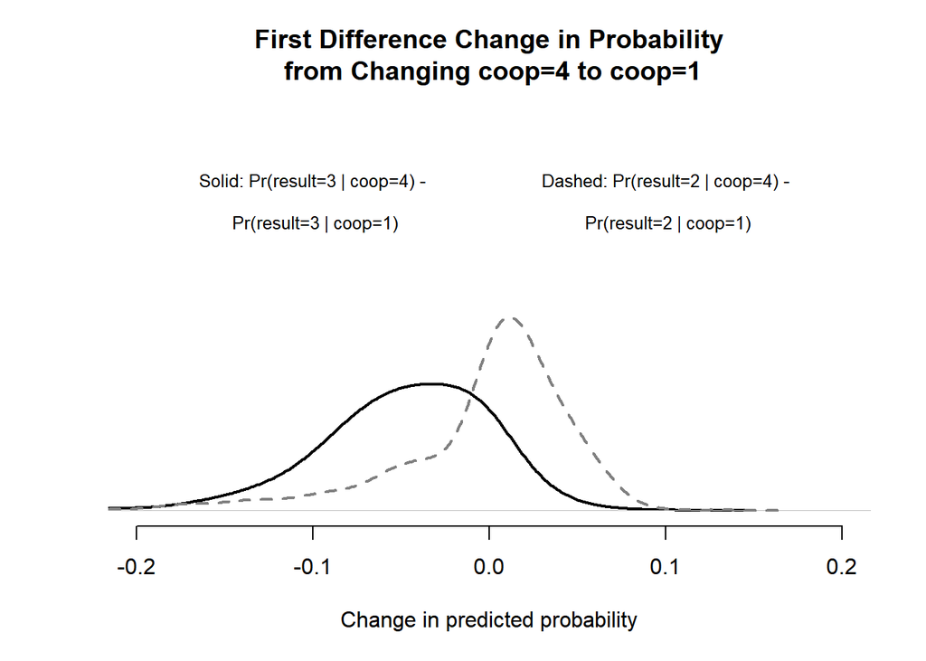

```r
X.coop1 <- cbind(median(log(gnprat)), median(drury$trade), median(tarcst), median(cost), min(coop)) # coop = 1 scenario

X.coop4 <- cbind(median(log(gnprat)), median(drury$trade), median(tarcst), median(cost), max(coop)) # coop = 4 scenario

draws<-mvrnorm(1000, c(coef(model_logit_drury),model_logit_drury$zeta),
               solve(model_logit_drury$Hessian))

B<-draws[,1:length(coef(model_logit_drury))]

Taus<-draws[,(length(coef(model_logit_drury))+1):ncol(draws)]

pi.cutoff12.coop1 <- plogis(Taus[,2] - B%*%t(X.coop1)) - plogis(Taus[,1] - B%*%t(X.coop1))
pi.cutoff12.coop4 <- plogis(Taus[,2] - B%*%t(X.coop4)) - plogis(Taus[,1] - B%*%t(X.coop4))
pi.cutoff23.coop1 <- plogis(Taus[,3] - B%*%t(X.coop1)) - plogis(Taus[,2] - B%*%t(X.coop1))
pi.cutoff23.coop4 <- plogis(Taus[,3] - B%*%t(X.coop4)) - plogis(Taus[,2] - B%*%t(X.coop4))

# result = 2 first difference
fd.res2 <- pi.cutoff12.coop4 - pi.cutoff12.coop1
# result = 3 first difference
fd.res3 <- pi.cutoff23.coop4 - pi.cutoff23.coop1

plot(density(fd.res3, adjust=1.5), xlim=c(-0.2,0.2),ylim=c(0,25),
     xlab="Change in predicted probability", bty="n", col=1,
     yaxt="n", lwd=2, main="First Difference Change in Probability\n from Changing coop=4 to coop=1",
     ylab="")
lines(density(fd.res2, adjust=1.5), col=grey(0.5), lwd=2, lty=2)
text(x=0.1, y=20, labels="Dashed: Pr(result=2 | coop=4) -
     \n Pr(result=2 | coop=1)",cex=.8)
text(x=-0.1, y=20, labels="Solid: Pr(result=3 | coop=4) -
     \n Pr(result=3 | coop=1)",cex=.8)
```

### Multinomial Logit

When are DV is binned into non-ordinal categories we can use a multinomial logit model.

Again, the derivation of the likelihood function for this class of models is fairly complicated (and taking its derivative analytically would be a nightmare) and so I’d guess it’s unlikely to be asked on the exam. See pg. 163-164 of Ward and Ahlquist (2018) for the relevant definitions.

#### Independence of Irrelevant Alternatives (IIA)

IIA is an assumption baked in to the standard multinomial logit model. It just means if we have some choices A and B for the DV then introducing some C won’t change the relative likelihood of someone choosing A over B.

#### Interpretation

Like with ordered logit, interpretation is kind of a nightmare. Essentially, each coefficient is the logit coefficient w.r.t. the excluded (reference) category of the DV for those columns of the BUTON. See pg. 169 of Ward and Ahlquist (2018) for an example of this. The first two columns of Table 9.1 present the logit coefficient of the given category w.r.t Labor.

## Count Data

Count models are used to describe count data ($Y\in{0,1,2, . . .}$). Count data is discrete and bounded from below.

### Why not use OLS?

This is a bad idea for the same reason it’s a bad idea to use OLS with binary data:

1. The variance of a count increases with the mean (more error around larger values) and thus count data is heteroskedastic.
2. OLS will generate predictions that aren’t lower bounded at 0 or integers. This can be worked around by logging the DV but then you have to deal with $\log(0)$. Do you discard these observations? Do you add some arbitrary constant to every value of your DV?

### Poisson Regression

#### The Poisson Distribution

Assumptions:

1. Events occur independently.
2. There is a constant arrival rate of events, $\lambda$. The probability of an event occurring in the interval $(t,t+h]$ is then $h\lambda$ (probability of a no event is $1-\lambda h$)

The distribution is then:

$$Y\sim f_p(y;\lambda,h)$$
$$Pr(Y=y)=\frac{e^{-h\lambda}(h\lambda)^y}{y!}$$
where $\lambda>0, h>0$

This is our *stochastic/random* component. The systematic component is some continuous or discrete set of IVs, $X$, that are linear in parameters (i.e. not squared, divided, etc.).

The mean and variance of the Poisson distribution is: $E[Y]=var(Y)=h\lambda$

If all observational intervals are the same length then we can let $h=1$ and the distribution simplifies to:

$$Pr(Y=y)=\frac{e^{-\lambda}\lambda^y}{y!}$$

The mean and variance of the Poisson distribution is then: $E[Y]=var(Y)=\lambda$

#### The Poisson Model

To incorporate covariates into a Poisson model where the mean is greater than zero, we need a link function to map our covariates, $x_i$, onto positive values. We use the exponential function:

$$E[Y_i]=h\lambda_i=he^{x_i^T\beta}$$

Or when $h=1$:

$$E[Y_i]=\lambda_i=e^{x_i^T\beta}$$

Plugging this value of $\lambda$ into our probability mass function we found defined above we get:

$$Pr(Y_i=y|x_i)=\frac{e^{-e^{x_i^T\beta}}[e^{x_i^T\beta}]^y} {y!}$$

We then derive the likelihood as follows:

$$\mathcal{L}(\beta|X,y)=\prod_{i=1}^n\frac{e^{-e^{x_i^T\beta}}[e^{x_i^T \beta}]^{y_i}}{y_i!}$$

We can drop the $\ln(y_i!)$ as it’s not a function of what we’re trying to maximize ($\beta$)

The score equation is:

$$\frac{\partial\ln\mathcal{L}}{\partial\beta}=\sum_{i=1}^n y_ix_i^T\beta-x_i^T\beta e^{x_i^T\beta}=\sum_{i=1}^n(y_i-e^{x_i^T\beta})x_i=0$$

#### Differential exposure

When observations have different exposure windows (i.e. $h$ is not constant across observational units) then we would expect their counts to be proportional to their exposure window. We have two choices for accounting for this:

1. Offset: Include the size of the exposure window in the regression but constrain its coefficient to be 1.0 i.e. $\lambda_i=e^{x_i^T\beta+\ln(h_i)}$
2. Control: Simply add the (log) of the exposure for each unit as a control in the regression

#### Interpretation

As with other non-linear models, directly interpreting coefficients isn’t the way to go. Instead, construct scenarios and generate predicted values to interpret results.

An example in R:

```r
# Load in the data
ms<-read.table("Data/Msrepl87.asc", header=TRUE,
    colClasses=c("character",rep("numeric",22)))
rownames(ms) <- ms$country

# Generate Poisson model
model_poisson <- glm(deaths75 ~ sanctions75 + pop75 + civlib76, data=ms,
                     family="poisson")

modelsummary(model_poisson, title="Poisson Model", stars=T)
```

Poisson Model

|  | Model 1 |
| --- | --- |
| (Intercept) | -0.019 |
|  | (0.015) |
| sanctions75 | 0.005*** |
|  | (0.000) |
| pop75 | -0.001*** |
|  | (0.000) |
| civlib76 | 1.455*** |
|  | (0.002) |
| Num.Obs. | 95 |
| AIC | 1844141.9 |
| BIC | 1844152.1 |
| Log.Lik. | -922066.951 |

+ p < 0.1, * p < 0.05, ** p < 0.01, *** p < 0.001

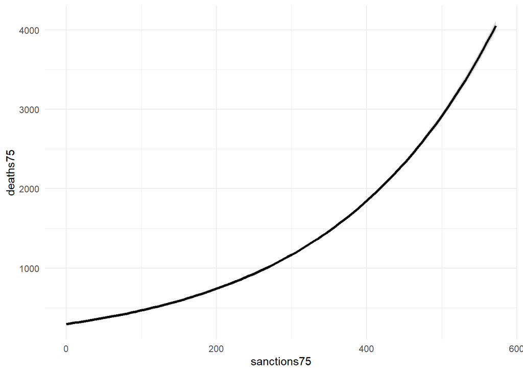

```r
# Now make a predicted value plot to interpret the effect of sanctions75
# on the probability of a death occurring

# Note this function automatically holds other IVs at their mean.

effect_plot(model_poisson, pred="sanctions75", interval=T) + theme_minimal()
```

#### Diagnostics

The Poisson distribution assumes that the level of heteroskedasticity will be constant. i.e. the variance will increase 1:1 with the mean of count data. This restrictive assumption is expressed as follows:

$$E[Y]=\mathrm{var}(Y)$$

We call it over-dispersion when $E[Y]<\mathrm{var}(Y)$ (most common) and under-dispersion when $E[Y]>\mathrm{var}(Y)$.

Obviously comparing the mean and variance of the DV is one way to assess dispersion. We can also use the `dispersiontest()` function from the `AER` library:

```r
AER::dispersiontest(model_poisson, alternative="two.sided")
```

```
##
##  Dispersion test
##
## data:  model_poisson
## z = 1.2539, p-value = 0.2099
## alternative hypothesis: true dispersion is not equal to 1
## sample estimates:
## dispersion
##   112512.2
```

To visually check for disperion we can use a Poissonness plot. Similar to a QQ plot, a perfectly dispersed DV will create a straight line in the plot. The Poissonness plot, however, does not tell us much about over-dispersion. For that we can use a hanging rootogram.

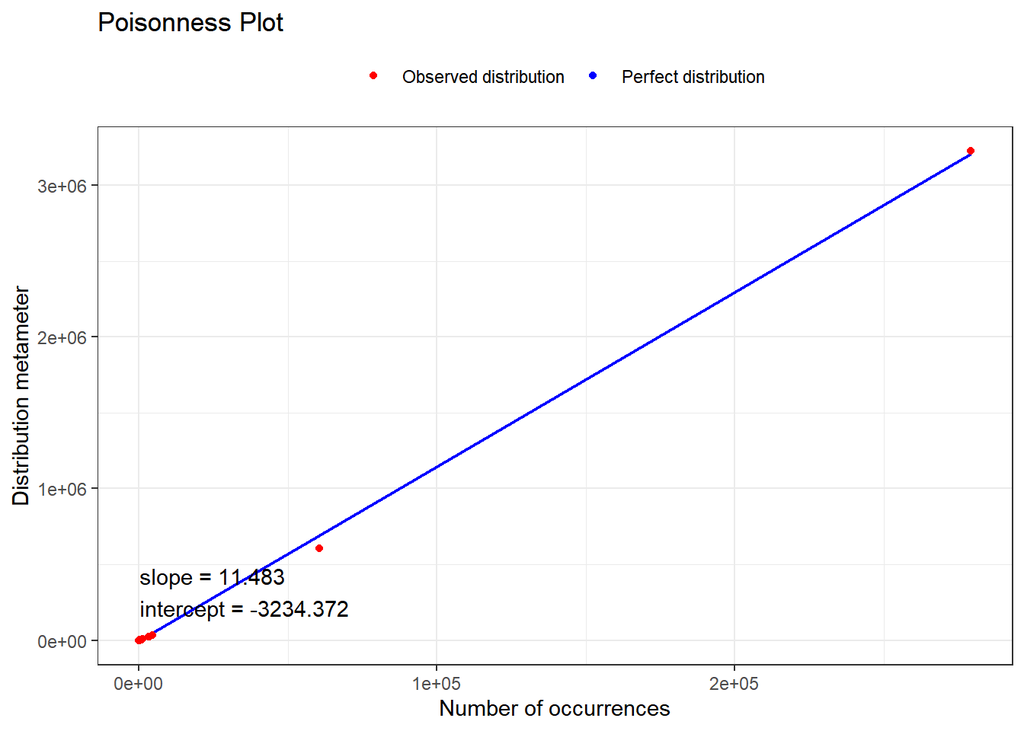

```r
# vcd has the distplot function to create a Poissonness plot but I went ahead and
# adapted it to output a ggplot

plotness::plotness(ms$deaths75)
```

#### Dealing with over-dispersion

So we have over-dispersion, what do we do?

1. Quasipoisson: Allows generating generating predicted counts and uncertainty estimates (which will be larger than a Poisson model) but without being able to assess model fit with information criteria or maximized likelihood.
2. Negative binomial: A model in which $\lambda_i$ is a random variable distributed as a gamma distribution but $Y_i$, conditional on $\lambda_i$, is still Poisson

```r
# Generate Poisson model
model_poisson <- glm(deaths75 ~ sanctions75 + pop75 + civlib76, data=ms,
                     family="poisson")

# Generate Poisson model
model_quasipoisson <- glm(deaths75 ~ sanctions75 + pop75 + civlib76, data=ms,
                     family="quasipoisson")


# Generate negative binomial model
model_negbin <- glm.nb(deaths75 ~ sanctions75 + pop75 + civlib76, data=ms)
modelsummary(list("Poisson Model"=model_poisson,
                  "Quasipoisson Model"=model_quasipoisson,
                  "Neg. Bin. Model"=model_negbin),
             title="Count Data Models", stars=T)
```

Count Data Models

|  | Poisson Model | Quasipoisson Model | Neg. Bin. Model |
| --- | --- | --- | --- |
| (Intercept) | -0.019 | -0.019 | 0.070 |
|  | (0.015) | (5.206) | (0.669) |
| sanctions75 | 0.005*** | 0.005 | 0.047*** |
|  | (0.000) | (0.005) | (0.003) |
| pop75 | -0.001*** | -0.001 | -0.010* |
|  | (0.000) | (0.013) | (0.004) |
| civlib76 | 1.455*** | 1.455+ | 1.164*** |
|  | (0.002) | (0.792) | (0.145) |
| Num.Obs. | 95 | 95 | 95 |
| AIC | 1844141.9 |  | 961.4 |
| BIC | 1844152.1 |  | 974.1 |
| Log.Lik. | -922066.951 |  | -475.682 |

+ p < 0.1, * p < 0.05, ** p < 0.01, *** p < 0.001

#### Dealing with under-dispersion

See Ward and Ahlquist (2018) for: Hurdle models (pg. 210) and zero-inflation models (pg. 211-212).

# 2021 Exam Questions and Answers

## 1 OLS

The attached dataset has a measure of party ideology ($Y$), a lagged measure of party ideology ($Y_\mathrm{lag}$),mean public opinion of group X ($X$), and mean public opinion of group Z ($Z$), in the variables $X$, $Y$, $Y_\mathrm{lag}$, and $Z$. The dataset is a time-series dataset organized by row, where row 1 corresponds to period 1, row 2 corresponds to period 2, etc. A scholar hypothesizes that party platforms change over time in response to current public opinion of group X and Z. Conduct your analysis below accordingly. Assume that public opinion change is exogenous.

1. Conduct a joint test of whether public opinion of group X and Z have any impact on party ideology. Explain the test you are using and conduct the test using your choice of software.

To test whether X and Z have a joint impact on Y, I conduct an F-test which compares an unrestricted OLS model containing the covariates of interest, $Y \sim X + Z$, to a restricted model wherein the mean of Y is predicted for each observation and only the intercept is estimated. In this F-test, the null hypothesis is that the coefficients on X and Z are zero and the two-tailed alternative hypothesis is that their coefficients are not zero. `R`’s `lm` function conducts a joint F-test for us when estimating the unrestricted model as follows:

```r
df_q1 <- read_csv("Methods_Comp_2021_Data/Question1data.csv")
```

```
## * `` -> ...1
```

```r
model_q1.1 <- lm(Y ~ X + Z, data=df_q1)
summary(model_q1.1)
```

```
##
## Call:
## lm(formula = Y ~ X + Z, data = df_q1)
##
## Residuals:
##      Min       1Q   Median       3Q      Max
## -13.1176  -6.2142   0.9135   5.9730  11.8183
##
## Coefficients:
##             Estimate Std. Error t value Pr(>|t|)
## (Intercept)  7.07155    0.42140  16.781   <2e-16 ***
## X            0.17513    0.39856   0.439    0.661
## Z            0.04635    0.19875   0.233    0.816
## ---
## Signif. codes:  0 '***' 0.001 '**' 0.01 '*' 0.05 '.' 0.1 ' ' 1
##
## Residual standard error: 6.637 on 247 degrees of freedom
## Multiple R-squared:  0.001027,   Adjusted R-squared:  -0.007062
## F-statistic: 0.127 on 2 and 247 DF,  p-value: 0.8808
```

The joint F-statistic is estimated at 0.127 with a p-value of 0.8808. If we set our significance threshold to $\alpha=.05$ or even $\alpha=.10$ then our F-statistic is not significant and thus the null hypothesis that the coefficients on X and Z are zero cannot be rejected. We thus conclude that there is no evidence here that the public opinion of groups X or Z have an impact on party ideology.

2. For 1.1, show the formula for the test statistic and explain each element in it. Explain why OR prove that the test you are using follows the distribution that is used in whatever test you use.

The F-statistic is defined as:

$$F=\frac{(SSR_{\mathrm{restricted}}-SSR_{\mathrm{unrestricted}})/q}{SSR_{\mathrm{unrestricted}}/(n-k-1)}$$

The joint F-test should follow an F-distribution. We can run the following simulation to see if the F statistics we get are distributed as we would expect under the null hypothesis:

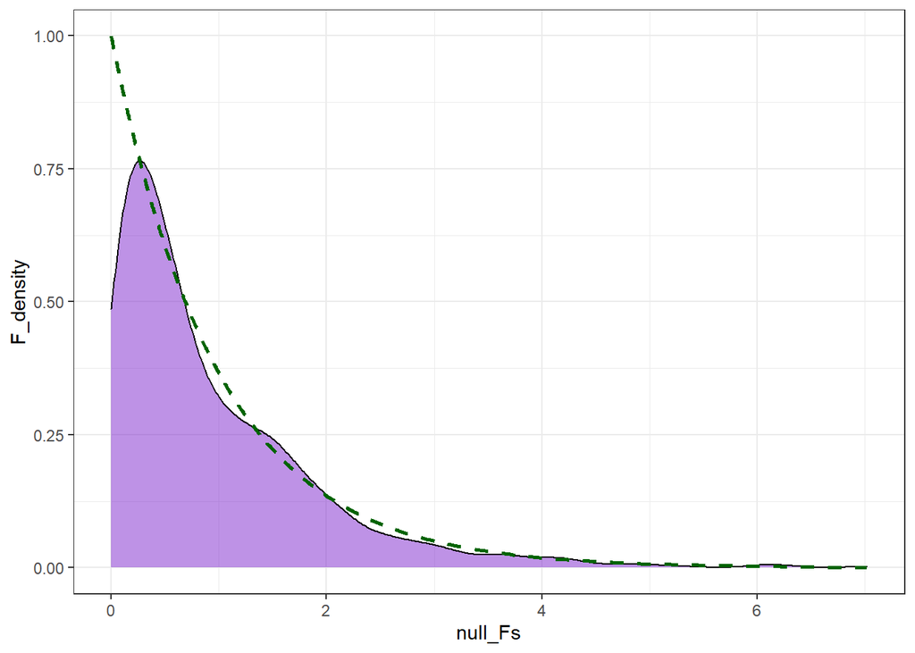

```r
# Note: simulation code adapted from Bert Wilden's answers to the exam
N <- 250
k <- 2
q <- 2
null_Fs <- c()

for(i in 1:1000){
  # Under the null our betas are 0
  b1_null <- 0
  b2_null <- 0

  # Generate normally distributed predicted values of Y as a function of X and Z
  # assuming the null is true
  y_null <- rnorm(N, mean=0 + (b1_null * df_q1$X) + (b2_null * df_q1$Z))


  # Fit the unrestricted model predicting y_null from X and Z
  model_null_ur <- lm(y_null ~ df_q1$X + df_q1$Z)

  # "Fitting" the restricted model with only the intercept will just give us the
  # mean of Y so we have:
  # model_null_r <- mean(y_null)
  model_null_r <- lm(y_null ~ 1)

  # Get the unrestricted sum of squares
  SSR_ur <- sum(resid(model_null_ur)^2)

  # Get the restricted sum of squares
  SSR_r <- sum(resid(model_null_r)^2)

  F_stat <- ((SSR_r-SSR_ur)/q)/(SSR_ur/(N-k-1))

  null_Fs <- c(null_Fs, F_stat)

}

# Coerce into a dataframe and calculate the density under the F distribution
# for each value of the F stat simulated under the null
sim.q1 <- data.frame(null_Fs) %>% mutate(F_density = df(null_Fs, k, N-k))

ggplot(sim.q1, aes(x=null_Fs)) +
  geom_density(fill="purple3", alpha=0.5, color="black") +
  geom_line(aes(y=F_density), color="darkgreen", linetype="dashed", lwd=1) +
  theme_bw()
```

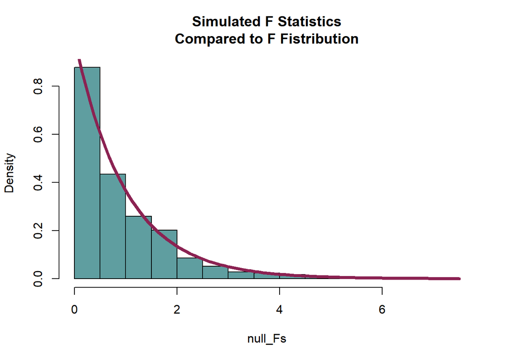

```r
# OR do it in base R graphics

hist(null_Fs, br=20, col="cadetblue", freq=F, main="Simulated F Statistics\nCompared to F Fistribution")
curve(df(x,k,250-k), add=T, lwd=4, col="violetred4")
```

We can see that the simulated values under the null (purple) approximately follows an F-distribution (green dashed line) as we would expect.

3. Does one group matter more than the other? Test whether political party platforms are more responsive to Group X than to Group Z. Explain the test, state null and alternative hypothesis, and conduct the test using your favorite software. Then, show the formula used in this test and explain each component of it. You do not need to repeat any explanation already presented in a previous response.

```r
model_q1.1 <- lm(Y ~ X + Z, data=df_q1)
summary(model_q1.1)
```

```
##
## Call:
## lm(formula = Y ~ X + Z, data = df_q1)
##
## Residuals:
##      Min       1Q   Median       3Q      Max
## -13.1176  -6.2142   0.9135   5.9730  11.8183
##
## Coefficients:
##             Estimate Std. Error t value Pr(>|t|)
## (Intercept)  7.07155    0.42140  16.781   <2e-16 ***
## X            0.17513    0.39856   0.439    0.661
## Z            0.04635    0.19875   0.233    0.816
## ---
## Signif. codes:  0 '***' 0.001 '**' 0.01 '*' 0.05 '.' 0.1 ' ' 1
##
## Residual standard error: 6.637 on 247 degrees of freedom
## Multiple R-squared:  0.001027,   Adjusted R-squared:  -0.007062
## F-statistic: 0.127 on 2 and 247 DF,  p-value: 0.8808
```

To test whether party ideology is better predicted by $X$ or $Z$ we re-estimate the OLS model containing both covariates as in 1.1. This time we focus in on the estimated coefficient and t-value for each covariate. The t-value is calculated as:

$$t=\frac{\hat{\beta}}{\hat{SE}_{\beta}}$$

where $\hat{\beta}$ is the coefficient estimate for the covariate tested and $\hat{SE}_{\beta}$ is the coefficient’s standard error. The null hypothesis is that the estimate for each covariate’s coefficient, $\hat{\beta}$ is zero. The alternative hypothesis is that it is non-zero.

We can see from the regression result that $X$ has a t-value of 0.439 and $Z$ has a t-value of 0.233. Though $X$’s estimated coefficient (0.18) is larger than $Z$’s (.05), neither t-statistic is statistically significant indicated by p-values for each coefficient $>.05$. The standard errors on the coefficients are sufficiently large that we cannot conclude that $X$ or $Z$ matter for predicting $Y$ and as such cannot conclude that the party is more responsive to one group over the other based on this model.

4. Now, suppose that opinions for Group Z are measured with error, so Z = true mean ideology + measurement error, where the measurement error is iid N(0, 1), and uncorrelated with $X$, $Y$ , $Y_\mathrm{lag}$, and $Z$ but opinions for Group X are not measured with error. How might that affect your conclusions from (3)? Develop your response with an analytic or simulated result to illustrate the problem.

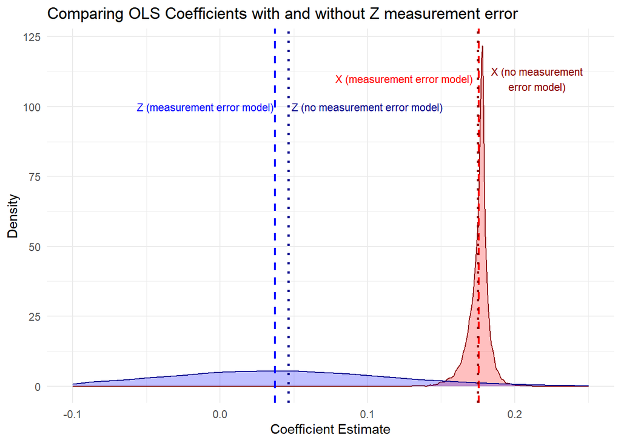

```r
set.seed(1234)

sim.q1.4 <- data.frame(beta_X_em = NA, SE_X_em = NA,
                       beta_Z_em = NA, SE_Z_em = NA)
# Run the simulation 10,000 times (1,000 isn't enough to see the biasing)
for(i in 1:10000){
  N <- 250

  # Add on normally distributed measurement error to Z
  df_q1$Z_witherror <- df_q1$Z + rnorm(n=N)

  # Estimate the model with measurement error
  model_Zerror <- lm(Y ~ X + Z_witherror, data=df_q1)

  # Pull out estimates
  beta_X_em <- summary(model_Zerror)$coefficients[2,1]
  SE_X_em <- summary(model_Zerror)$coefficients[2,2]

  beta_Z_em <- summary(model_Zerror)$coefficients[3,1]
  SE_Z_em <- summary(model_Zerror)$coefficients[3,2]

  sim.q1.4 <- rbind(sim.q1.4, c(beta_X_em, SE_X_em,
                                beta_Z_em, SE_Z_em))
}

sim.q1.4 %>%
  drop_na() %>%
  ggplot(aes()) +
    geom_density(aes(x=beta_X_em), fill="red", alpha=0.25, color="darkred") +
    geom_density(aes(x=beta_Z_em), fill="blue", alpha=0.25, color="darkblue") +
    geom_vline(aes(xintercept=mean(beta_X_em)), color="red", lwd=.8,
               linetype="dashed") +
    geom_vline(aes(xintercept=summary(model_q1.1)$coefficients[2,1]),
               color="darkred", linetype="dotted", lwd=1) +
    geom_vline(aes(xintercept=mean(beta_Z_em)), color="blue", lwd=.8,
               linetype="dashed") +
    geom_vline(aes(xintercept=summary(model_q1.1)$coefficients[3,1]),
               linetype="dotted", color="darkblue", lwd=1) +
    xlim(c(-0.1,0.25)) +
    labs(x="Coefficient Estimate", y="Density",
         title="Comparing OLS Coefficients with and without Z measurement error") +
    theme_minimal() +
    annotate("text", x=-.01, y=100, label="Z (measurement error model)",
             color="blue", size=3) +
    annotate("text", x=.1, y=100, label="Z (no measurement error model)",
             color="darkblue", size=3) +
    annotate("text", x=0.125, y=110, label="X (measurement error model)",
             color="red",size=3) +
    annotate("text", x=.215, y=110, label="X (no measurement\nerror model)",
             color="darkred", size=3)
```